# Regression analysis

Jessica Couture

March 15, 2018

## Background

This analysis accompanies the manuscript “Funder imposed data publication requirements seldom inspire data sharing”, assessing results of a two year data archiving effort by a group of researchers and students at the National Center for Ecological Analysis and Synthesis at UC Santa Barbara. The [Exxon Valdez Oil Spill Trustee Council](http://www.evostc.state.ak.us) (EVOSTC) was formed following the Exxon Valdez oil spill in Alaska in 1989. Since then, the EVOSTC has funded hundreds of projects and in 2012 an effort was initiated to recover and archive the data collected through these EVOSTC funded projects. The recovery effort spanned two years.

For this paper we ask 3 main questions about the data collected from the Exxon Valdez Oil Spill Trustee Council funded projects:

1. Twenty-five years after the EVOS, for how many projects funded by EVOSTC can we collect data?
2. Are there differences in data reporting based on characteristics of the data?
- Research field
- Sector of researching body
- Year data projects ended
3. Which of these characteristics are most *important* in determining if a dataset will be successfully recovered and how do the important characteristics influence the output (success)?

## Binomial regression

In order to assess how the percent recovery is influenced by time, data type and agency we are running an logistic regression on all 3 factors.

```r
blrDat<-rslt2 %>%
  select(age,dataType,statSucc,agSubGrp)

mod<-glm(statSucc~.,family = binomial(link="logit"),data=blrDat)

summary(mod)
```

```
##
## Call:
## glm(formula = statSucc ~ ., family = binomial(link = "logit"),
##     data = blrDat)
##
## Deviance Residuals:
##     Min       1Q   Median       3Q      Max
## -1.4839  -0.7544  -0.6347   1.0350   2.1540
##
## Coefficients:
##                     Estimate Std. Error z value Pr(>|z|)
## (Intercept)        -0.211299   0.649127  -0.326   0.7448
## age                 0.003926   0.025240   0.156   0.8764
## dataTypebirds      -0.815963   0.559783  -1.458   0.1449
## dataTypefish       -1.170844   0.535555  -2.186   0.0288 *
## dataTypehabitat    -1.190769   0.678245  -1.756   0.0791 .
## dataTypemammals    -0.717978   0.615339  -1.167   0.2433
## dataTypemodeling  -16.382176 720.906131  -0.023   0.9819
## dataTypeoil        -0.140457   0.606569  -0.232   0.8169
## dataTypephysical    0.477153   0.657545   0.726   0.4680
## dataTypeplankton   -0.654774   1.336036  -0.490   0.6241
## dataTypesocial     -1.881887   0.907154  -2.074   0.0380 *
## agSubGrpakNative    1.348768   1.465440   0.920   0.3574
## agSubGrpgov_fed    -0.195064   0.408662  -0.477   0.6331
## agSubGrpgov_state  -0.170233   0.443209  -0.384   0.7009
## agSubGrpnonProf     0.391655   0.534362   0.733   0.4636
## agSubGrpprivate     0.024819   0.583796   0.043   0.9661
## ---
## Signif. codes:  0 '***' 0.001 '**' 0.01 '*' 0.05 '.' 0.1 ' ' 1
##
## (Dispersion parameter for binomial family taken to be 1)
##
##     Null deviance: 352.45  on 303  degrees of freedom
## Residual deviance: 324.77  on 288  degrees of freedom
##   (11 observations deleted due to missingness)
## AIC: 356.77
##
## Number of Fisher Scoring iterations: 15
```

```r
# ageMod<-glm(statSucc~end-1,family = binomial(link="logit"),data=blrDat)
# summary(ageMod)
```

# Chi-sq tests from Regression:

```r
library(aod)

timeChi<-wald.test(b = coef(mod), Sigma = vcov(mod), Terms = 2)

typeChi<-wald.test(b = coef(mod), Sigma = vcov(mod), Terms = 3:11)

agChi<-wald.test(b = coef(mod), Sigma = vcov(mod), Terms = 12:16)
```

Chi-sq for age of data = 0.8763739

Chi-sq for data type = 0.0465513

Chi-sq for agency = 0.7601266

These chi-sq results match what we found before: only data-type is significant ___

## Binomial regression: “START”

Playing with the data I saw that then stats are run using “start” instead of “end” for age of data, we get a lot more significance. I know we decided on “end” for a reason but might be worth discussing in our group and maybe adding to the discussion.

```r
strtDat<-rslt2 %>%
  select(start,dataType,statSucc,agSubGrp)

modSt<-glm(statSucc~.,family = binomial(link="logit"),data=strtDat)

summary(modSt)
```

```
##
## Call:
## glm(formula = statSucc ~ ., family = binomial(link = "logit"),
##     data = strtDat)
##
## Deviance Residuals:
##     Min       1Q   Median       3Q      Max
## -1.4065  -0.7708  -0.6081   0.9106   2.4711
##
## Coefficients:
##                    Estimate Std. Error z value Pr(>|z|)
## (Intercept)       189.95350   52.91891   3.590 0.000331 ***
## start              -0.09528    0.02652  -3.593 0.000327 ***
## dataTypebirds      -0.92538    0.57035  -1.622 0.104703
## dataTypefish       -1.09628    0.54645  -2.006 0.044837 *
## dataTypehabitat    -1.05255    0.69163  -1.522 0.128047
## dataTypemammals    -0.86108    0.63760  -1.351 0.176854
## dataTypemodeling  -16.24943  707.71310  -0.023 0.981682
## dataTypeoil        -0.09281    0.62045  -0.150 0.881094
## dataTypephysical    0.72653    0.68078   1.067 0.285878
## dataTypeplankton   -0.65765    1.33440  -0.493 0.622126
## dataTypesocial     -1.99161    0.94189  -2.114 0.034474 *
## agSubGrpakNative    1.84445    1.51956   1.214 0.224823
## agSubGrpgov_fed    -0.19064    0.41831  -0.456 0.648573
## agSubGrpgov_state  -0.40801    0.45119  -0.904 0.365834
## agSubGrpnonProf     0.56589    0.55023   1.028 0.303730
## agSubGrpprivate     0.18276    0.59255   0.308 0.757750
## ---
## Signif. codes:  0 '***' 0.001 '**' 0.01 '*' 0.05 '.' 0.1 ' ' 1
##
## (Dispersion parameter for binomial family taken to be 1)
##
##     Null deviance: 352.45  on 303  degrees of freedom
## Residual deviance: 310.68  on 288  degrees of freedom
##   (11 observations deleted due to missingness)
## AIC: 342.68
##
## Number of Fisher Scoring iterations: 15
```

```r
ageMod<-glm(statSucc~start-1,family = binomial(link="logit"),data=strtDat)
#summary(ageMod)
```

# Chi-sq tests from Regression:

```r
library(aod)

timeChiSt<-wald.test(b = coef(modSt), Sigma = vcov(modSt), Terms = 2)

typeChiSt<-wald.test(b = coef(modSt), Sigma = vcov(modSt), Terms = 3:11)

agChiSt<-wald.test(b = coef(modSt), Sigma = vcov(modSt), Terms = 12:16)
```

Chi-sq for age of data = 3.274700910^{-4}

Chi-sq for data type = 0.0295422

Chi-sq for agency = 0.3743549

*Using “start” the age of data is in fact SIGNIFICANT along with data type*

```
##
##     1973 1975 1978 1982 1984 1989 1990 1991 1992 1993 1994 1995 1996 1997
##   0    0    0    0    0    0   37    1    4   11   11   22   27   18   11
##   1    1    1    1    1    1   23    4    2    3    4    6    4    0    5
##
##     1998 1999 2000 2001 2002 2003 2004 2005 2006 2007 2009 2010
##   0   13   17   10    6   13    8   11    3    1    9    1    0
##   1    2    1    7    1    0    3    3    3    1    3    0    1
```

```
##
##  Pearson's Chi-squared test
##
## data:  startProps
## X-squared = 54.9, df = 25, p-value = 0.0005071
```

# Distributions of “start” vs “end” data

“End” data are more evenly distributed so *should* give us a better idea of trends over time.

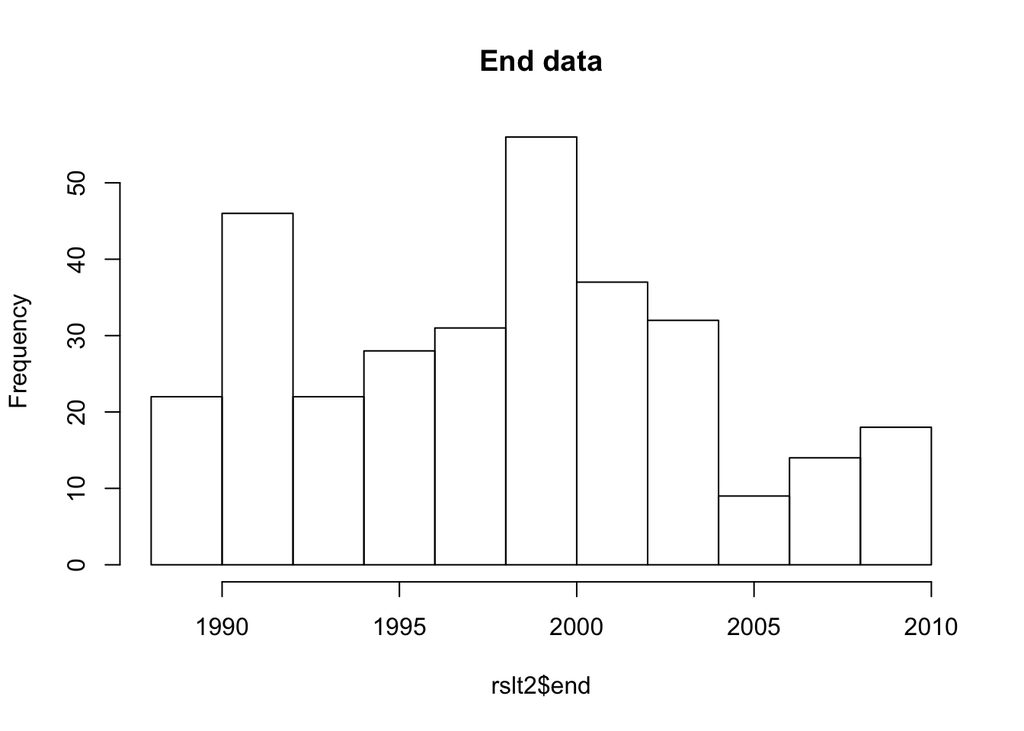

```r
hist(rslt2$end,main = "End data")
```

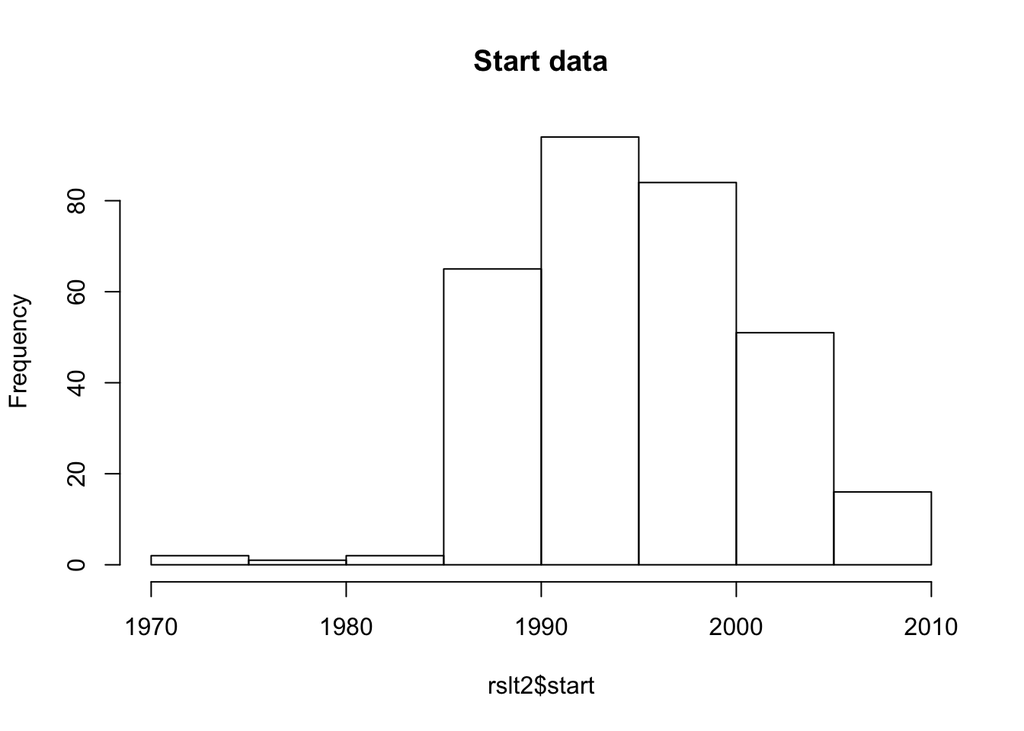

```r
hist(rslt2$start,main = "Start data")
```

# Vines nested analysis attempt:

In his paper, “The Availability of Research Data Declines Rapidly with Article Age,” Vines et al. use a nested approach to assess their results through recovery success. This approach isolates the probability of success at each successive step. Our steps are outlined as follows:

- Nest 1: # outreach/total projects
- Nest 2: # replies/# outreach
- Nest 3: # data received/# replies
- Nest 4: # published datasets/# data received

### Nest 1: Confirmed contact info (“emailed”+)

```r
nest<-rslt2 %>%
  mutate(pContInf=ifelse(is.na(reason),1,ifelse(reason=="no contact info",0,1))) %>% #use all date
  mutate(pRepl=ifelse(Status=="Emailed",0,1)) %>% # remove "no contact info" values when analyzing --> of those that we had contact info for, how many replied?
  mutate(pSent=ifelse(Status=="SentData",1,ifelse(Status=="Published",1,0))) %>% # rm "no contact info" & emailed data when analyzing --> of those that 'replied' which sent data?
  mutate(pPub=ifelse(Status=="Published",1,0))

nest1blm<-glm(pContInf~age+dataType+agSubGrp,family = binomial(link="logit"),data=nest)

summary(nest1blm)
```

```
##
## Call:
## glm(formula = pContInf ~ age + dataType + agSubGrp, family = binomial(link = "logit"),
##     data = nest)
##
## Deviance Residuals:
##      Min        1Q    Median        3Q       Max
## -2.85983   0.07142   0.18621   0.36853   1.15510
##
## Coefficients:
##                     Estimate Std. Error z value Pr(>|z|)
## (Intercept)          6.59682    1.75770   3.753 0.000175 ***
## age                 -0.19636    0.06181  -3.177 0.001489 **
## dataTypebirds        2.32861    1.23456   1.886 0.059270 .
## dataTypefish         0.33886    0.84288   0.402 0.687666
## dataTypehabitat     -0.72367    0.93124  -0.777 0.437096
## dataTypemammals     17.35407 1702.26609   0.010 0.991866
## dataTypemodeling    16.95447 2986.76416   0.006 0.995471
## dataTypeoil         -0.13590    0.91810  -0.148 0.882323
## dataTypephysical     0.52688    1.28743   0.409 0.682358
## dataTypeplankton    15.19007 6082.80102   0.002 0.998008
## dataTypesocial      -0.24821    1.14481  -0.217 0.828356
## agSubGrpakNative    14.56793 7307.22851   0.002 0.998409
## agSubGrpgov_fed     -1.31854    1.14454  -1.152 0.249307
## agSubGrpgov_state   -1.89192    1.09699  -1.725 0.084591 .
## agSubGrpnonProf     -0.54850    1.55260  -0.353 0.723879
## agSubGrpprivate     -1.97359    1.33763  -1.475 0.140093
## ---
## Signif. codes:  0 '***' 0.001 '**' 0.01 '*' 0.05 '.' 0.1 ' ' 1
##
## (Dispersion parameter for binomial family taken to be 1)
##
##     Null deviance: 152.76  on 303  degrees of freedom
## Residual deviance: 114.72  on 288  degrees of freedom
##   (11 observations deleted due to missingness)
## AIC: 146.72
##
## Number of Fisher Scoring iterations: 18
```

```r
summary(nest1b<-glm(pContInf~age,family = binomial(link = "logit"),data=nest))
```

```
##
## Call:
## glm(formula = pContInf ~ age, family = binomial(link = "logit"),
##     data = nest)
##
## Deviance Residuals:
##     Min       1Q   Median       3Q      Max
## -2.9880   0.2209   0.3195   0.5015   0.8321
##
## Coefficients:
##             Estimate Std. Error z value Pr(>|z|)
## (Intercept)  5.20414    0.80884   6.434 1.24e-10 ***
## age         -0.18789    0.04476  -4.197 2.70e-05 ***
## ---
## Signif. codes:  0 '***' 0.001 '**' 0.01 '*' 0.05 '.' 0.1 ' ' 1
##
## (Dispersion parameter for binomial family taken to be 1)
##
##     Null deviance: 198.13  on 314  degrees of freedom
## Residual deviance: 175.78  on 313  degrees of freedom
## AIC: 179.78
##
## Number of Fisher Scoring iterations: 6
```

```r
nest1Pl<-nest %>%
  group_by(age) %>%
  mutate(annProj=n()) %>%
  mutate(annRepl=sum(pContInf)) %>%
  mutate(pRplAnn=annRepl/annProj) %>%
  filter(!duplicated(age)) %>%
  select(Status,age,pContInf,annProj,annRepl,pRplAnn)
```

### Nest 2: replied given we found contact info (“Replied”+)

```r
nest2<-nest %>%
  filter(is.na(reason) | reason !="no contact info")

nest2blm<-glm(pRepl~age+dataType+agSubGrp,family = binomial(link="logit"),data=nest2)

summary(nest2blm)
```

```
##
## Call:
## glm(formula = pRepl ~ age + dataType + agSubGrp, family = binomial(link = "logit"),
##     data = nest2)
##
## Deviance Residuals:
##     Min       1Q   Median       3Q      Max
## -2.2003   0.3901   0.5337   0.6952   1.4633
##
## Coefficients:
##                     Estimate Std. Error z value Pr(>|z|)
## (Intercept)        17.243758 955.959481   0.018    0.986
## age                 0.001897   0.030884   0.061    0.951
## dataTypebirds     -15.678202 955.959452  -0.016    0.987
## dataTypefish      -16.269361 955.959397  -0.017    0.986
## dataTypehabitat   -16.540762 955.959478  -0.017    0.986
## dataTypemammals   -15.825293 955.959490  -0.017    0.987
## dataTypemodeling  -15.153335 955.959932  -0.016    0.987
## dataTypeoil       -15.579178 955.959567  -0.016    0.987
## dataTypephysical  -15.478911 955.959653  -0.016    0.987
## dataTypeplankton  -16.651691 955.960175  -0.017    0.986
## dataTypesocial    -17.928804 955.959535  -0.019    0.985
## agSubGrpakNative   -0.990523   1.467694  -0.675    0.500
## agSubGrpgov_fed     0.273330   0.442469   0.618    0.537
## agSubGrpgov_state   0.551394   0.504859   1.092    0.275
## agSubGrpnonProf     0.254547   0.604737   0.421    0.674
## agSubGrpprivate     0.291050   0.746252   0.390    0.697
##
## (Dispersion parameter for binomial family taken to be 1)
##
##     Null deviance: 272.96  on 282  degrees of freedom
## Residual deviance: 247.82  on 267  degrees of freedom
##   (2 observations deleted due to missingness)
## AIC: 279.82
##
## Number of Fisher Scoring iterations: 16
```

### Nest 3: Sent data given we received a response (“SentData”+)

```r
nest3<-nest2 %>%
  filter(!Status=="Emailed")

nest3blm<-glm(pSent~age+dataType+agSubGrp,family = binomial(link="logit"),data=nest3)

summary(nest3blm)
```

```
##
## Call:
## glm(formula = pSent ~ age + dataType + agSubGrp, family = binomial(link = "logit"),
##     data = nest3)
##
## Deviance Residuals:
##     Min       1Q   Median       3Q      Max
## -1.6692  -0.8693  -0.7501   1.1413   1.8204
##
## Coefficients:
##                     Estimate Std. Error z value Pr(>|z|)
## (Intercept)         -0.19867    0.68411  -0.290   0.7715
## age                  0.02641    0.02782   0.950   0.3423
## dataTypebirds       -0.96473    0.59901  -1.611   0.1073
## dataTypefish        -1.05393    0.57058  -1.847   0.0647 .
## dataTypehabitat     -0.77314    0.74530  -1.037   0.2996
## dataTypemammals     -0.69820    0.65316  -1.069   0.2851
## dataTypemodeling   -16.70451  753.74117  -0.022   0.9823
## dataTypeoil         -0.05485    0.68086  -0.081   0.9358
## dataTypephysical     0.63270    0.73738   0.858   0.3909
## dataTypeplankton    -0.21743    1.52265  -0.143   0.8865
## dataTypesocial      -0.75982    1.01131  -0.751   0.4525
## agSubGrpakNative    17.71301 2399.54476   0.007   0.9941
## agSubGrpgov_fed     -0.24549    0.43598  -0.563   0.5734
## agSubGrpgov_state   -0.22639    0.47696  -0.475   0.6350
## agSubGrpnonProf      0.40959    0.58000   0.706   0.4801
## agSubGrpprivate      0.16341    0.62721   0.261   0.7944
## ---
## Signif. codes:  0 '***' 0.001 '**' 0.01 '*' 0.05 '.' 0.1 ' ' 1
##
## (Dispersion parameter for binomial family taken to be 1)
##
##     Null deviance: 297.20  on 229  degrees of freedom
## Residual deviance: 269.95  on 214  degrees of freedom
##   (2 observations deleted due to missingness)
## AIC: 301.95
##
## Number of Fisher Scoring iterations: 15
```

```r
# summary(glm(pSent~age,family = binomial(link="logit"),data=nest3))
```

Our variables were not significance indicators as to whether data were sent given responses were received.

### Nest 4: Data were published given we received data (“Published”)

```r
nest4<-nest3 %>%
  filter(Status %in% c("SentData","Published"))

nest4blm<-glm(pPub~age+dataType+agSubGrp,family = binomial(link="logit"),data=nest4)
summary(nest4blm)
```

```
##
## Call:
## glm(formula = pPub ~ age + dataType + agSubGrp, family = binomial(link = "logit"),
##     data = nest4)
##
## Deviance Residuals:
##      Min        1Q    Median        3Q       Max
## -1.62533  -0.44066   0.00006   0.38304   2.19043
##
## Coefficients:
##                     Estimate Std. Error z value Pr(>|z|)
## (Intercept)        4.858e+00  2.106e+00   2.307   0.0211 *
## age               -1.394e-01  7.139e-02  -1.952   0.0509 .
## dataTypebirds     -1.159e+00  1.343e+00  -0.863   0.3879
## dataTypefish      -2.981e-01  1.281e+00  -0.233   0.8160
## dataTypehabitat    1.828e+01  7.308e+03   0.003   0.9980
## dataTypemammals    1.230e-01  1.372e+00   0.090   0.9285
## dataTypeoil       -2.036e+00  1.479e+00  -1.376   0.1687
## dataTypephysical   1.868e+01  4.369e+03   0.004   0.9966
## dataTypeplankton  -6.657e-01  1.837e+04   0.000   1.0000
## dataTypesocial     1.828e+01  1.062e+04   0.002   0.9986
## agSubGrpakNative   1.656e+01  1.773e+04   0.001   0.9993
## agSubGrpgov_fed   -2.012e+00  1.237e+00  -1.626   0.1040
## agSubGrpgov_state -1.921e+00  1.400e+00  -1.372   0.1702
## agSubGrpnonProf    1.679e+01  4.799e+03   0.003   0.9972
## agSubGrpprivate    1.799e+01  5.440e+03   0.003   0.9974
## ---
## Signif. codes:  0 '***' 0.001 '**' 0.01 '*' 0.05 '.' 0.1 ' ' 1
##
## (Dispersion parameter for binomial family taken to be 1)
##
##     Null deviance: 92.105  on 79  degrees of freedom
## Residual deviance: 49.214  on 65  degrees of freedom
## AIC: 79.214
##
## Number of Fisher Scoring iterations: 19
```

Our variables were not significance indicators as to whether data were complete enough to publish given data were sent.